# Exercise 2

## Imports

```python
from pathlib import Path
import copy

import torch
import torch.nn as nn
from torch.utils.data import DataLoader
from torch.utils.tensorboard import SummaryWriter
from torchvision import datasets, models, transforms
from torchvision.transforms import v2
```

## Dataset Path

```python
data_dir = Path("dataset")  # train/, valid/, test/
```

## Transforms

```python
train_transform = transforms.Compose([
    transforms.Resize((224, 224)),

    # Spatial augmentations
    transforms.RandomHorizontalFlip(p=0.5),
    transforms.RandomRotation(10),

    # Non-spatial augmentation
    transforms.ColorJitter(
        brightness=0.2,
        contrast=0.2,
        saturation=0.2,
        hue=0.05,
    ),

    transforms.ToTensor(),
    transforms.Normalize(
        mean=[0.485, 0.456, 0.406],
        std=[0.229, 0.224, 0.225],
    ),
])

eval_transform = transforms.Compose([
    transforms.Resize((224, 224)),
    transforms.ToTensor(),
    transforms.Normalize(
        mean=[0.485, 0.456, 0.406],
        std=[0.229, 0.224, 0.225],
    ),
])
```

## Datasets

```python
train_dataset = datasets.ImageFolder(data_dir / "train", transform=train_transform)
valid_dataset = datasets.ImageFolder(data_dir / "valid", transform=eval_transform)
test_dataset = datasets.ImageFolder(data_dir / "test", transform=eval_transform)

n_classes = len(train_dataset.classes)

batch_size = 32
num_workers = 2
```

## Dataset Summary

```python
print("Classes:", train_dataset.classes)
print("Train:", len(train_dataset), "Valid:", len(valid_dataset), "Test:", len(test_dataset))
```

```
Classes: ['human', 'robot']
Train: 411 Valid: 89 Test: 89
```

## CutMix and MixUp

```python
cutmix = v2.CutMix(num_classes=n_classes, alpha=1.0)
mixup = v2.MixUp(num_classes=n_classes, alpha=0.2)

cutmix_or_mixup = v2.RandomChoice([cutmix, mixup])
```

## DataLoader Collate Function

```python
def collate_fn(batch):
    images, labels = torch.utils.data.default_collate(batch)
    return cutmix_or_mixup(images, labels)
```

## DataLoaders

```python
BATCH_SIZE = 16

train_loader = DataLoader(
    train_dataset,
    batch_size=BATCH_SIZE,
    shuffle=True,
    collate_fn=collate_fn,
)

valid_loader = DataLoader(valid_dataset, batch_size=BATCH_SIZE, shuffle=False)
test_loader = DataLoader(test_dataset, batch_size=BATCH_SIZE, shuffle=False)
```

```python
images, labels = next(iter(train_loader))
print(images.shape)
print(labels.shape)
```

```
torch.Size([16, 3, 224, 224])
torch.Size([16, 2])
```

## CNN Model Builder

```python
def build_cnn_model(model_name, strategy="feature_extractor", num_classes=2):
    if model_name == "resnet50":
        weights = models.ResNet50_Weights.DEFAULT
        model = models.resnet50(weights=weights)
        num_ftrs = model.fc.in_features
    elif model_name == "efficientnet_b0":
        weights = models.EfficientNet_B0_Weights.DEFAULT
        model = models.efficientnet_b0(weights=weights)
        num_ftrs = model.classifier[1].in_features
    elif model_name == "convnext_tiny":
        weights = models.ConvNeXt_Tiny_Weights.DEFAULT
        model = models.convnext_tiny(weights=weights)
        num_ftrs = model.classifier[2].in_features

    if strategy == "feature_extractor" or strategy == "combined":
        for param in model.parameters():
            param.requires_grad = False

    head = nn.Linear(num_ftrs, num_classes)

    if model_name == "resnet50":
        model.fc = head
    elif model_name == "efficientnet_b0":
        model.classifier[1] = head
    elif model_name == "convnext_tiny":
        model.classifier[2] = head

    return model
```

## Device Setup

```python
device = torch.device("cuda" if torch.cuda.is_available() else "cpu")

print("Device:", device)
```

```
Device: cuda
```

## Training Function

```python
def train_model(
    model,
    train_loader,
    valid_loader,
    criterion,
    optimizer,
    scheduler,
    device,
    num_epochs=10,
    writer=None,
):
    history = {
        "train_loss": [],
        "valid_loss": [],
        "valid_acc": [],
        "lr": [],
    }

    best_valid_acc = 0.0
    best_model_state = copy.deepcopy(model.state_dict())

    for epoch in range(num_epochs):
        model.train()
        running_train_loss = 0.0

        for images, labels in train_loader:
            images = images.to(device)
            labels = labels.to(device)

            optimizer.zero_grad()

            outputs = model(images)
            loss = criterion(outputs, labels)

            loss.backward()
            optimizer.step()

            running_train_loss += loss.item() * images.size(0)

        epoch_train_loss = running_train_loss / len(train_loader.dataset)

        model.eval()
        running_valid_loss = 0.0
        correct = 0
        total = 0

        with torch.no_grad():
            for images, labels in valid_loader:
                images = images.to(device)
                labels = labels.to(device)

                outputs = model(images)
                loss = criterion(outputs, labels)

                running_valid_loss += loss.item() * images.size(0)

                preds = outputs.argmax(dim=1)
                correct += (preds == labels).sum().item()
                total += labels.size(0)

        epoch_valid_loss = running_valid_loss / len(valid_loader.dataset)
        epoch_valid_acc = 100.0 * correct / total
        current_lr = optimizer.param_groups[0]["lr"]

        history["train_loss"].append(epoch_train_loss)
        history["valid_loss"].append(epoch_valid_loss)
        history["valid_acc"].append(epoch_valid_acc)
        history["lr"].append(current_lr)

        if epoch_valid_acc > best_valid_acc:
            best_valid_acc = epoch_valid_acc
            best_model_state = copy.deepcopy(model.state_dict())

        if writer is not None:
            epoch_number = epoch + 1
            writer.add_scalar("Loss/train", epoch_train_loss, epoch_number)
            writer.add_scalar("Loss/valid", epoch_valid_loss, epoch_number)
            writer.add_scalar("Accuracy/valid", epoch_valid_acc, epoch_number)
            writer.add_scalar("LearningRate", current_lr, epoch_number)

        if scheduler is not None:
            scheduler.step()

        print(
            f"Epoch [{epoch + 1}/{num_epochs}] "
            f"Train Loss: {epoch_train_loss:.4f} "
            f"Valid Loss: {epoch_valid_loss:.4f} "
            f"Valid Acc: {epoch_valid_acc:.2f}%"
        )

    model.load_state_dict(best_model_state)
    return history
```

## Evaluation Function

```python
def evaluate_model(model, data_loader, criterion, device):
    model.eval()

    running_loss = 0.0
    correct = 0
    total = 0

    all_preds = []
    all_labels = []
    all_probs = []

    with torch.no_grad():
        for images, labels in data_loader:
            images = images.to(device)
            labels = labels.to(device)

            outputs = model(images)
            loss = criterion(outputs, labels)

            running_loss += loss.item() * images.size(0)

            probs = torch.softmax(outputs, dim=1)
            preds = outputs.argmax(dim=1)

            correct += (preds == labels).sum().item()
            total += labels.size(0)

            all_preds.extend(preds.cpu().tolist())
            all_labels.extend(labels.cpu().tolist())
            all_probs.extend(probs.cpu().tolist())

    avg_loss = running_loss / len(data_loader.dataset)
    accuracy = 100.0 * correct / total

    return {
        "loss": avg_loss,
        "accuracy": accuracy,
        "preds": all_preds,
        "labels": all_labels,
        "probs": all_probs,
    }
```

## CNN Experiment Runner

```python
def run_cnn_experiment(
    model_name,
    strategy="fine_tune",
    num_epochs=3,
    lr=1e-4,
    step_size=5,
    gamma=0.3,
):
    model = build_cnn_model(
        model_name=model_name,
        strategy=strategy,
        num_classes=n_classes,
    ).to(device)

    criterion = nn.CrossEntropyLoss()
    optimizer = torch.optim.Adam(
        filter(lambda p: p.requires_grad, model.parameters()),
        lr=lr,
    )
    scheduler = torch.optim.lr_scheduler.StepLR(
        optimizer,
        step_size=step_size,
        gamma=gamma,
    )

    log_dir = f"tboard_logs/{model_name}_{strategy}"
    writer = SummaryWriter(log_dir=log_dir)

    all_params = sum(p.numel() for p in model.parameters())
    trainable_params = sum(p.numel() for p in model.parameters() if p.requires_grad)
    print(f"\nTraining {model_name} ({strategy})")
    print("TensorBoard log dir:", log_dir)
    print("All parameters:", all_params)
    print("Trainable parameters:", trainable_params)

    history = train_model(
        model=model,
        train_loader=train_loader,
        valid_loader=valid_loader,
        criterion=criterion,
        optimizer=optimizer,
        scheduler=scheduler,
        device=device,
        num_epochs=num_epochs,
        writer=writer,
    )

    test_results = evaluate_model(
        model=model,
        data_loader=test_loader,
        criterion=criterion,
        device=device,
    )

    writer.close()

    return {
        "model_name": model_name,
        "strategy": strategy,
        "model": model,
        "history": history,
        "test_results": test_results,
        "all_params": all_params,
        "trainable_params": trainable_params,
        "log_dir": log_dir,
    }
```

## Train CNN Models

```python
CNN_MODEL_NAMES = ["resnet50", "efficientnet_b0", "convnext_tiny"]
CNN_STRATEGY = "fine_tune"
CNN_NUM_EPOCHS = 5

cnn_results = {}

for model_name in CNN_MODEL_NAMES:
    cnn_results[model_name] = run_cnn_experiment(
        model_name=model_name,
        strategy=CNN_STRATEGY,
        num_epochs=CNN_NUM_EPOCHS,
    )
```

```
Downloading: "https://download.pytorch.org/models/resnet50-11ad3fa6.pth" to /home/user/rosatellif1/.cache/torch/hub/checkpoints/resnet50-11ad3fa6.pth
```

```
Training resnet50 (fine_tune)
TensorBoard log dir: tboard_logs/resnet50_fine_tune
All parameters: 23512130
Trainable parameters: 23512130
Epoch [1/5] Train Loss: 0.5981 Valid Loss: 0.3023 Valid Acc: 98.88%
Epoch [2/5] Train Loss: 0.3940 Valid Loss: 0.1552 Valid Acc: 98.88%
Epoch [3/5] Train Loss: 0.3359 Valid Loss: 0.1437 Valid Acc: 98.88%
Epoch [4/5] Train Loss: 0.2898 Valid Loss: 0.1162 Valid Acc: 98.88%
Epoch [5/5] Train Loss: 0.2869 Valid Loss: 0.1151 Valid Acc: 98.88%
```

```
Downloading: "https://download.pytorch.org/models/efficientnet_b0_rwightman-7f5810bc.pth" to /home/user/rosatellif1/.cache/torch/hub/checkpoints/efficientnet_b0_rwightman-7f5810bc.pth
```

```
Training efficientnet_b0 (fine_tune)
TensorBoard log dir: tboard_logs/efficientnet_b0_fine_tune
All parameters: 4010110
Trainable parameters: 4010110
Epoch [1/5] Train Loss: 0.6262 Valid Loss: 0.4145 Valid Acc: 95.51%
Epoch [2/5] Train Loss: 0.4290 Valid Loss: 0.2282 Valid Acc: 97.75%
Epoch [3/5] Train Loss: 0.3705 Valid Loss: 0.1472 Valid Acc: 98.88%
Epoch [4/5] Train Loss: 0.3252 Valid Loss: 0.1338 Valid Acc: 97.75%
Epoch [5/5] Train Loss: 0.3407 Valid Loss: 0.1277 Valid Acc: 98.88%
```

```
Downloading: "https://download.pytorch.org/models/convnext_tiny-983f1562.pth" to /home/user/rosatellif1/.cache/torch/hub/checkpoints/convnext_tiny-983f1562.pth
```

```
Training convnext_tiny (fine_tune)
TensorBoard log dir: tboard_logs/convnext_tiny_fine_tune
All parameters: 27821666
Trainable parameters: 27821666
Epoch [1/5] Train Loss: 0.4287 Valid Loss: 0.0541 Valid Acc: 100.00%
Epoch [2/5] Train Loss: 0.3104 Valid Loss: 0.0880 Valid Acc: 98.88%
Epoch [3/5] Train Loss: 0.3064 Valid Loss: 0.0588 Valid Acc: 100.00%
Epoch [4/5] Train Loss: 0.2763 Valid Loss: 0.0437 Valid Acc: 100.00%
Epoch [5/5] Train Loss: 0.2502 Valid Loss: 0.0321 Valid Acc: 100.00%
```

## CNN Results Summary

```python
cnn_summary = []

for model_name, result in cnn_results.items():
    best_valid_acc = max(result["history"]["valid_acc"])
    best_valid_epoch = result["history"]["valid_acc"].index(best_valid_acc) + 1
    test_acc = result["test_results"]["accuracy"]
    test_loss = result["test_results"]["loss"]

    cnn_summary.append({
        "model": model_name,
        "strategy": result["strategy"],
        "best_valid_acc": best_valid_acc,
        "best_valid_epoch": best_valid_epoch,
        "test_acc": test_acc,
        "test_loss": test_loss,
    })

for row in cnn_summary:
    print(
        f"{row['model']} ({row['strategy']}): "
        f"best valid acc = {row['best_valid_acc']:.2f}% "
        f"at epoch {row['best_valid_epoch']} | "
        f"test acc = {row['test_acc']:.2f}% | "
        f"test loss = {row['test_loss']:.4f}"
    )
```

```
resnet50 (fine_tune): best valid acc = 98.88% at epoch 1 | test acc = 95.51% | test loss = 0.3398
efficientnet_b0 (fine_tune): best valid acc = 98.88% at epoch 3 | test acc = 96.63% | test loss = 0.1552
convnext_tiny (fine_tune): best valid acc = 100.00% at epoch 1 | test acc = 96.63% | test loss = 0.1099
```

## ResNet50 Combined Strategy

```python
def run_resnet50_combined_experiment(
    head_epochs=3,
    finetune_epochs=3,
    head_lr=1e-4,
    finetune_lr=1e-5,
    step_size=5,
    gamma=0.3,
):
    model = build_cnn_model(
        model_name="resnet50",
        strategy="feature_extractor",
        num_classes=n_classes,
    ).to(device)

    criterion = nn.CrossEntropyLoss()

    all_params = sum(p.numel() for p in model.parameters())
    phase1_trainable_params = sum(p.numel() for p in model.parameters() if p.requires_grad)
    print("\nTraining resnet50 (combined)")
    print("Phase 1: classifier head only")
    print("All parameters:", all_params)
    print("Trainable parameters:", phase1_trainable_params)

    phase1_writer = SummaryWriter(log_dir="tboard_logs/resnet50_combined_phase1_head")
    phase1_optimizer = torch.optim.Adam(
        filter(lambda p: p.requires_grad, model.parameters()),
        lr=head_lr,
    )
    phase1_scheduler = torch.optim.lr_scheduler.StepLR(
        phase1_optimizer,
        step_size=step_size,
        gamma=gamma,
    )

    phase1_history = train_model(
        model=model,
        train_loader=train_loader,
        valid_loader=valid_loader,
        criterion=criterion,
        optimizer=phase1_optimizer,
        scheduler=phase1_scheduler,
        device=device,
        num_epochs=head_epochs,
        writer=phase1_writer,
    )
    phase1_writer.close()

    for param in model.layer4.parameters():
        param.requires_grad = True

    phase2_trainable_params = sum(p.numel() for p in model.parameters() if p.requires_grad)
    print("Phase 2: layer4 + classifier head")
    print("Trainable parameters:", phase2_trainable_params)

    phase2_writer = SummaryWriter(log_dir="tboard_logs/resnet50_combined_phase2_layer4")
    phase2_optimizer = torch.optim.Adam(
        filter(lambda p: p.requires_grad, model.parameters()),
        lr=finetune_lr,
    )
    phase2_scheduler = torch.optim.lr_scheduler.StepLR(
        phase2_optimizer,
        step_size=step_size,
        gamma=gamma,
    )

    phase2_history = train_model(
        model=model,
        train_loader=train_loader,
        valid_loader=valid_loader,
        criterion=criterion,
        optimizer=phase2_optimizer,
        scheduler=phase2_scheduler,
        device=device,
        num_epochs=finetune_epochs,
        writer=phase2_writer,
    )
    phase2_writer.close()

    test_results = evaluate_model(
        model=model,
        data_loader=test_loader,
        criterion=criterion,
        device=device,
    )

    return {
        "model_name": "resnet50",
        "strategy": "combined",
        "model": model,
        "phase1_history": phase1_history,
        "phase2_history": phase2_history,
        "test_results": test_results,
        "all_params": all_params,
        "phase1_trainable_params": phase1_trainable_params,
        "phase2_trainable_params": phase2_trainable_params,
    }
```

## Train ResNet50 Strategies

```python
RESNET50_STRATEGY_EPOCHS = 5

resnet50_strategy_results = {}

resnet50_strategy_results["feature_extractor"] = run_cnn_experiment(
    model_name="resnet50",
    strategy="feature_extractor",
    num_epochs=RESNET50_STRATEGY_EPOCHS,
)

if "resnet50" in cnn_results:
    resnet50_strategy_results["fine_tune"] = cnn_results["resnet50"]
    print("Reusing fine-tuned ResNet50 result from cnn_results.")
else:
    resnet50_strategy_results["fine_tune"] = run_cnn_experiment(
        model_name="resnet50",
        strategy="fine_tune",
        num_epochs=RESNET50_STRATEGY_EPOCHS,
    )

resnet50_strategy_results["combined"] = run_resnet50_combined_experiment(
    head_epochs=RESNET50_STRATEGY_EPOCHS,
    finetune_epochs=RESNET50_STRATEGY_EPOCHS,
)
```

```
Training resnet50 (feature_extractor)
TensorBoard log dir: tboard_logs/resnet50_feature_extractor
All parameters: 23512130
Trainable parameters: 4098
Epoch [1/5] Train Loss: 0.6596 Valid Loss: 0.6062 Valid Acc: 83.15%
Epoch [2/5] Train Loss: 0.6169 Valid Loss: 0.5544 Valid Acc: 92.13%
Epoch [3/5] Train Loss: 0.5696 Valid Loss: 0.5053 Valid Acc: 95.51%
Epoch [4/5] Train Loss: 0.5358 Valid Loss: 0.4507 Valid Acc: 95.51%
Epoch [5/5] Train Loss: 0.4930 Valid Loss: 0.4123 Valid Acc: 95.51%
Reusing fine-tuned ResNet50 result from cnn_results.

Training resnet50 (combined)
Phase 1: classifier head only
All parameters: 23512130
Trainable parameters: 4098
Epoch [1/5] Train Loss: 0.6666 Valid Loss: 0.6334 Valid Acc: 86.52%
Epoch [2/5] Train Loss: 0.6149 Valid Loss: 0.5643 Valid Acc: 94.38%
Epoch [3/5] Train Loss: 0.5730 Valid Loss: 0.5196 Valid Acc: 94.38%
Epoch [4/5] Train Loss: 0.5490 Valid Loss: 0.4787 Valid Acc: 96.63%
Epoch [5/5] Train Loss: 0.5402 Valid Loss: 0.4461 Valid Acc: 96.63%
Phase 2: layer4 + classifier head
Trainable parameters: 14968834
Epoch [1/5] Train Loss: 0.5306 Valid Loss: 0.4336 Valid Acc: 98.88%
Epoch [2/5] Train Loss: 0.4632 Valid Loss: 0.3769 Valid Acc: 98.88%
Epoch [3/5] Train Loss: 0.4564 Valid Loss: 0.3467 Valid Acc: 100.00%
Epoch [4/5] Train Loss: 0.4422 Valid Loss: 0.3112 Valid Acc: 100.00%
Epoch [5/5] Train Loss: 0.3921 Valid Loss: 0.2739 Valid Acc: 100.00%
```

## ResNet50 Strategy Summary

```python
resnet50_strategy_summary = []

for strategy, result in resnet50_strategy_results.items():
    if strategy == "combined":
        valid_accs = result["phase1_history"]["valid_acc"] + result["phase2_history"]["valid_acc"]
        best_valid_acc = max(valid_accs)
        best_valid_epoch = valid_accs.index(best_valid_acc) + 1
    else:
        best_valid_acc = max(result["history"]["valid_acc"])
        best_valid_epoch = result["history"]["valid_acc"].index(best_valid_acc) + 1

    resnet50_strategy_summary.append({
        "strategy": strategy,
        "best_valid_acc": best_valid_acc,
        "best_valid_epoch": best_valid_epoch,
        "test_acc": result["test_results"]["accuracy"],
        "test_loss": result["test_results"]["loss"],
    })

for row in resnet50_strategy_summary:
    print(
        f"resnet50 ({row['strategy']}): "
        f"best valid acc = {row['best_valid_acc']:.2f}% "
        f"at epoch {row['best_valid_epoch']} | "
        f"test acc = {row['test_acc']:.2f}% | "
        f"test loss = {row['test_loss']:.4f}"
    )
```

```
resnet50 (feature_extractor): best valid acc = 95.51% at epoch 3 | test acc = 97.75% | test loss = 0.5291
resnet50 (fine_tune): best valid acc = 98.88% at epoch 1 | test acc = 95.51% | test loss = 0.3398
resnet50 (combined): best valid acc = 100.00% at epoch 8 | test acc = 97.75% | test loss = 0.3655
```

## DINOv2 Classifier

```python
class DINOv2Classifier(nn.Module):
    def __init__(self, num_classes=2):
        super().__init__()
        self.backbone = torch.hub.load("facebookresearch/dinov2", "dinov2_vits14")

        for param in self.backbone.parameters():
            param.requires_grad = False

        self.head = nn.Linear(384, num_classes)

    def forward(self, x):
        features = self.backbone(x)
        return self.head(features)
```

## DINOv2 Experiment Runner

```python
def run_dinov2_experiment(
    num_epochs=3,
    lr=1e-4,
    step_size=5,
    gamma=0.3,
):
    model = DINOv2Classifier(num_classes=n_classes).to(device)

    criterion = nn.CrossEntropyLoss()
    optimizer = torch.optim.Adam(
        filter(lambda p: p.requires_grad, model.parameters()),
        lr=lr,
    )
    scheduler = torch.optim.lr_scheduler.StepLR(
        optimizer,
        step_size=step_size,
        gamma=gamma,
    )

    log_dir = "tboard_logs/dinov2_feature_extractor"
    writer = SummaryWriter(log_dir=log_dir)

    all_params = sum(p.numel() for p in model.parameters())
    trainable_params = sum(p.numel() for p in model.parameters() if p.requires_grad)
    print("\nTraining DINOv2 (feature_extractor)")
    print("TensorBoard log dir:", log_dir)
    print("All parameters:", all_params)
    print("Trainable parameters:", trainable_params)

    history = train_model(
        model=model,
        train_loader=train_loader,
        valid_loader=valid_loader,
        criterion=criterion,
        optimizer=optimizer,
        scheduler=scheduler,
        device=device,
        num_epochs=num_epochs,
        writer=writer,
    )

    test_results = evaluate_model(
        model=model,
        data_loader=test_loader,
        criterion=criterion,
        device=device,
    )

    writer.close()

    return {
        "model_name": "dinov2_vits14",
        "strategy": "feature_extractor",
        "model": model,
        "history": history,
        "test_results": test_results,
        "all_params": all_params,
        "trainable_params": trainable_params,
        "log_dir": log_dir,
    }
```

## Train DINOv2

```python
DINO_NUM_EPOCHS = 5

dinov2_result = run_dinov2_experiment(
    num_epochs=DINO_NUM_EPOCHS,
)
```

```
Downloading: "https://github.com/facebookresearch/dinov2/zipball/main" to /home/user/rosatellif1/.cache/torch/hub/main.zip
Downloading: "https://dl.fbaipublicfiles.com/dinov2/dinov2_vits14/dinov2_vits14_pretrain.pth" to /home/user/rosatellif1/.cache/torch/hub/checkpoints/dinov2_vits14_pretrain.pth
```

```
Training DINOv2 (feature_extractor)
TensorBoard log dir: tboard_logs/dinov2_feature_extractor
All parameters: 22057346
Trainable parameters: 770
Epoch [1/5] Train Loss: 0.9645 Valid Loss: 0.7530 Valid Acc: 61.80%
Epoch [2/5] Train Loss: 0.7161 Valid Loss: 0.5655 Valid Acc: 70.79%
Epoch [3/5] Train Loss: 0.6268 Valid Loss: 0.4331 Valid Acc: 80.90%
Epoch [4/5] Train Loss: 0.5446 Valid Loss: 0.3554 Valid Acc: 83.15%
Epoch [5/5] Train Loss: 0.4828 Valid Loss: 0.2980 Valid Acc: 86.52%
```

## DINOv2 Results Summary

```python
best_valid_acc = max(dinov2_result["history"]["valid_acc"])
best_valid_epoch = dinov2_result["history"]["valid_acc"].index(best_valid_acc) + 1
test_acc = dinov2_result["test_results"]["accuracy"]
test_loss = dinov2_result["test_results"]["loss"]

print(
    f"DINOv2 ({dinov2_result['strategy']}): "
    f"best valid acc = {best_valid_acc:.2f}% "
    f"at epoch {best_valid_epoch} | "
    f"test acc = {test_acc:.2f}% | "
    f"test loss = {test_loss:.4f}"
)
```

```
DINOv2 (feature_extractor): best valid acc = 86.52% at epoch 5 | test acc = 86.52% | test loss = 0.3634
```

# Confusion Matrix

[figure not shown]

[figure not shown]

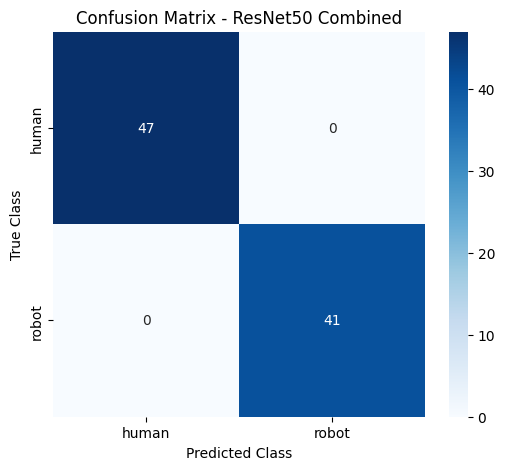

```
[ResNet50 Combined] No Errors Found! 100% Accuracy on this set.
```

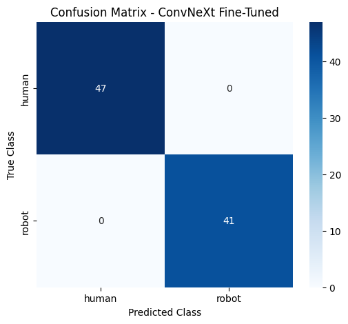

```
[ConvNeXt Fine-Tuned] No Errors Found! 100% Accuracy on this set.
```

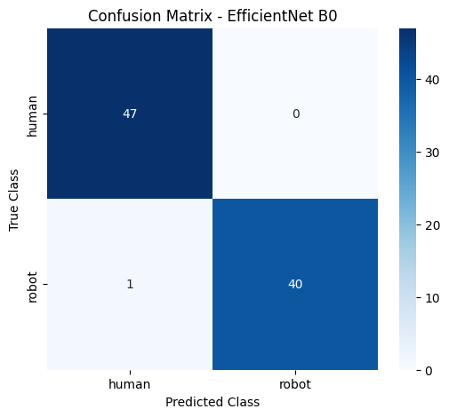

[figure not shown]

```python
import matplotlib.pyplot as plt
import seaborn as sns
from sklearn.metrics import confusion_matrix
import numpy as np

def evaluate_and_analyze(model, dataloader, dataset_classes, model_name):
    model.eval()
    all_preds = []
    all_labels = []
    failures = []

    with torch.no_grad():
        for inputs, labels in dataloader:
            inputs, labels = inputs.to(device), labels.to(device)
            outputs = model(inputs)
            _, predicted = outputs.max(1)

            all_preds.extend(predicted.cpu().numpy())
            all_labels.extend(labels.cpu().numpy())

            for i in range(len(labels)):
                if predicted[i] != labels[i]:
                    failures.append({
                        'image': inputs[i].cpu(),
                        'true_label': dataset_classes[labels[i].item()],
                        'predicted': dataset_classes[predicted[i].item()]
                    })

    cm = confusion_matrix(all_labels, all_preds)
    plt.figure(figsize=(6, 5))
    sns.heatmap(cm, annot=True, fmt='d', cmap='Blues',
                xticklabels=dataset_classes, yticklabels=dataset_classes)
    plt.xlabel('Predicted Class')
    plt.ylabel('True Class')
    plt.title(f'Confusion Matrix - {model_name}')
    plt.show()

    if failures:
        num_to_plot = min(5, len(failures))
        fig, axes = plt.subplots(1, num_to_plot, figsize=(15, 3))
        if num_to_plot == 1: axes = [axes]

        for idx, ax in enumerate(axes):
            img = failures[idx]['image'].permute(1, 2, 0).numpy()
            img = img * np.array([0.229, 0.224, 0.225]) + np.array([0.485, 0.456, 0.406])
            img = np.clip(img, 0, 1)

            ax.imshow(img)
            ax.set_title(f"True: {failures[idx]['true_label']}\nPred: {failures[idx]['predicted']}", color="red")
            ax.axis('off')
        #plt.title(f"Misclassified - {model_name}", fontsize=14)
        plt.show()
    else:
        print(f"[{model_name}] No Errors Found! 100% Accuracy on this set.")


evaluate_and_analyze(dinov2_result["model"], valid_loader, train_dataset.classes, "DINOv2 Fine-Tuned")
evaluate_and_analyze(resnet50_strategy_results["combined"]["model"], valid_loader, train_dataset.classes, "ResNet50 Combined")
evaluate_and_analyze(cnn_results["convnext_tiny"]["model"], valid_loader, train_dataset.classes, "ConvNeXt Fine-Tuned")
evaluate_and_analyze(cnn_results["efficientnet_b0"]["model"], valid_loader, train_dataset.classes, "EfficientNet B0")
```

# Evaluation

In our fine-tuning experiments across different CNN architectures, ConvNeXt-Tiny demonstrated the fastest convergence and the strongest feature extraction capabilities, reaching a perfect Validation Accuracy of 100.00% by the very first epoch. When evaluated on the test set, both ConvNeXt-Tiny and EfficientNet-B0 achieved a strong Test Accuracy of 96.63%, outperforming ResNet50 (95.51%). Furthermore, ConvNeXt-Tiny achieved the lowest test loss overall (0.1099 compared to EfficientNet's 0.1552 and ResNet's 0.3398), confirming its superiority as a modern, highly efficient architecture for this binary classification task.

We compared three different training strategies using ResNet50:

- Fixed Feature Extractor: Achieved a Test Accuracy of 97.75% with a Test Loss of 0.5291.
- Full Fine-Tuning: Reached 98.88% Validation Accuracy but dropped to 95.51% Test Accuracy (Loss: 0.3398).
- Combined Approach (2 Phases): Reached 100.00% Validation Accuracy and matched the highest Test Accuracy of 97.75%, but with a significantly lower Test Loss (0.3655) compared to the fixed extractor.

These results highlight a classic case of overfitting during full fine-tuning: since our dataset is relatively small, unfreezing all 23.5 million parameters caused the model to over-adapt to the training data, hurting its generalization on the test set. The Combined Approach proved to be the most robust strategy: by warming up the classifier head first and only unfreezing the top layers (layer4) later, we achieved the best balance between adapting to the specific domain (robots vs. humans) and retaining the robust generalizations learned from ImageNet.